# Airlines Delay

### Airline on-time statistics and delay causes

##### by Muhammad Elkfrawy - Dec 2020

## Preliminary Wrangling

> The U.S. Department of Transportation's (DOT) [Bureau of Transportation Statistics](https://www.transtats.bts.gov/OT_Delay/OT_DelayCause1.asp) (BTS) tracks the on-time performance of domestic flights operated by large air carriers. Summary information on the number of on-time, delayed, canceled, and diverted flights appear in DOT's monthly [Air Travel Consumer Report](http://www.dot.gov/individuals/air-consumer/air-travel-consumer-reports), published about 30 days after the month's end, as well as in summary tables posted on this website. BTS began collecting details on the causes of flight delays in June 2003. Summary statistics and raw data are made available to the public at the time the Air Travel Consumer Report is released.

*This version of the dataset was compiled from the Statistical Computing Statistical Graphics 2009 Data Expo and is also [available here](http://stat-computing.org/dataexpo/2009/the-data.html) or [here](https://dataverse.harvard.edu/dataset.xhtml?persistentId=doi:10.7910/DVN/HG7NV7).*

## Univariate Exploration

In this section, we will investigate distributions of individual variables. If we see unusual points or outliers, we will take a deeper look to clean things up and prepare to look at relationships between variables.

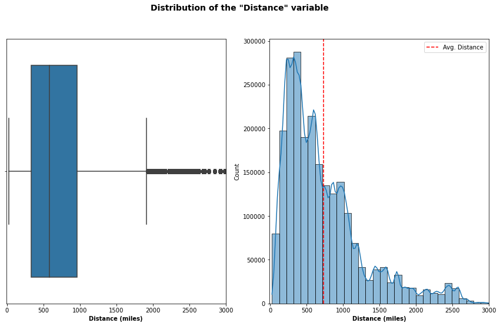

- Obviously, a right-skewed distribution, with a mean value around 750 miles.
- More than 75% of the flights that haven't been canceled were less than 1000 miles in distance.

**Let's first check the ratio of canceled flights and diverted flights.**

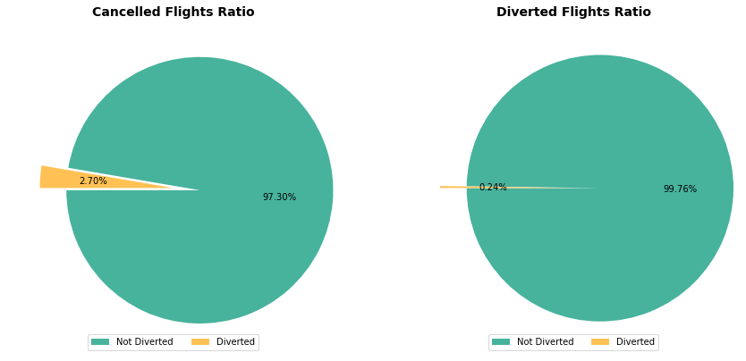

**From the above two pie charts we discovered that:**

- 2.7% of the flights *(in this data)* have been canceled.
- Only 0.24% of the flights were diverted.

**Let's dig deeper and check for reasons by plot the bar chart for the reasons.**

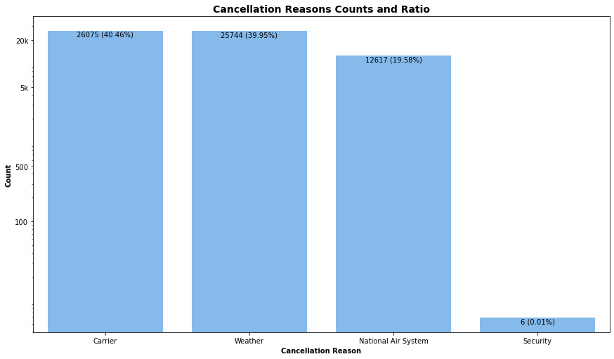

- From the above, it turns out that most flight cancelation flights were due to carrier and weather reasons with almost 40% each. Followed by National Air System with around 20%. And the security reasons had the least effect.

**Let's ask some time related questions, How many canceled flights per month?**

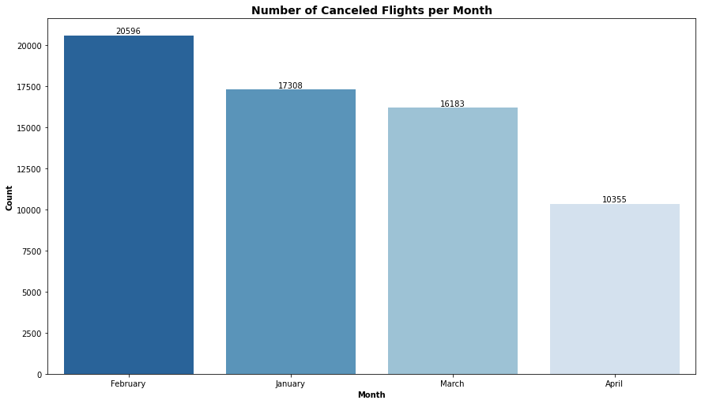

- From the above, the most canceled flights were in February. I think due to the bad weather because it is winter in February.

**And which day had the most canceled flights on?**

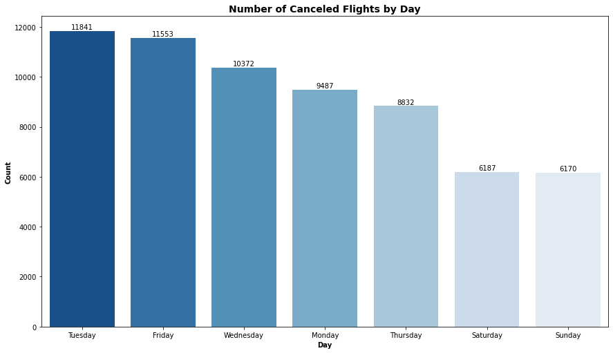

- Don't travel on Tuesdays of Fridays as the most canceled flights happened on them. Travel on weekends!

## Bivariate Exploration

In this section, we will investigate relationships between pairs of variables in the data and study the distributions and the most factors.

#### What is the relationship between Arrival delay and the Departure delay?

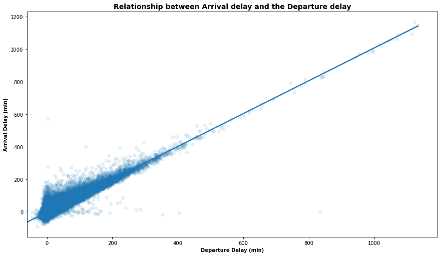

- As expected, a positive correlation. If the flight took off late, definitely it will arrive late.

#### Let's check the relationship between Distance and Arrival Delay.

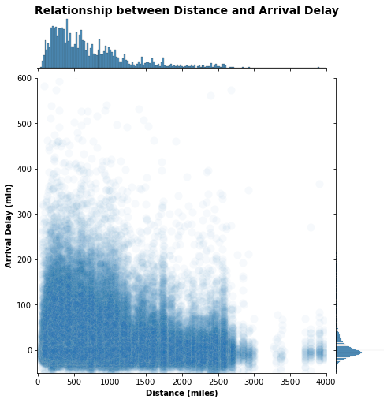

#### Now, let's have a look at the time-related columns.

**So, what is the best hour to book a flight?**

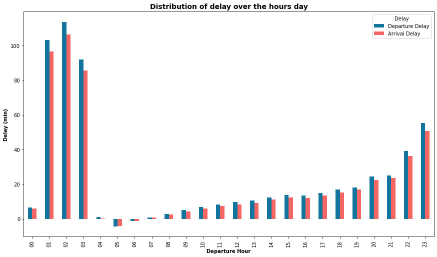

- From the above, we can confirm the early hours of the day *(04:00 AM to 07:00 AM)* are the best hours to book a flight as they have the least delays.

**And What if we have an award for the carrier with the most delayed flights, who will get it?**

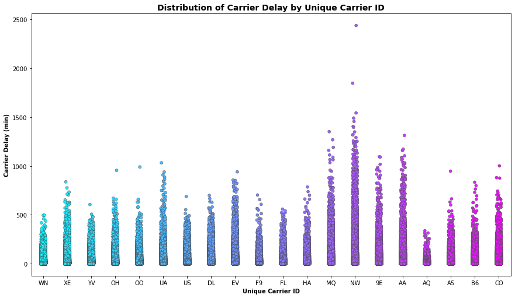

- The Northwest Airlines Inc. (NW) had the most delayed flights due to carrier delay, followed by American Eagle Airlines Inc. (MQ) and American Airlines Inc. (AA).

## Multivariate Exploration

We will create plots of three or more variables to investigate the data even further.

#### Let's focus and investigate more about Northwest Airlines Inc., American Airlines Inc. and American Eagle Airlines Inc.

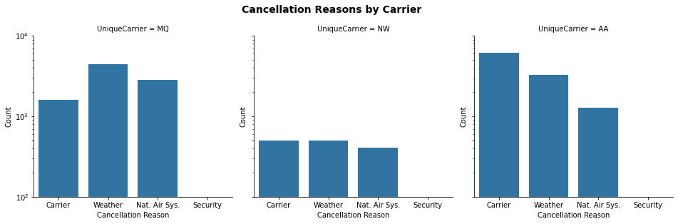

- As with all carriers, American Airlines Inc. and Northwest Airlines Inc. their canceled flights happened due to carrier and weather reasons. on the other hand, American Eagle Airlines Inc.'s most of its canceled flights happened due to weather reasons.

**Let's check the relationship between arrival delay and distance for these carriers**

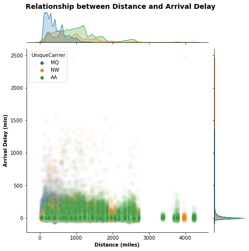

- That match what we have found before, but for American Eagle Airlines Inc.'s shortest flights arrived more later than the longest ones than the other carriers